# HW 2 - Ajay Kallepalli

### Objective:

The objective of this homework assignment is to deepen your understanding of the Word2Vec algorithm, its implementation, and its applications in natural language processing.

### Instructions:

- Implement Word2Vec using the gensim library in Python. You can choose a preprocessed text dataset or use your own.
- Train Word2Vec on the dataset and experiment with different hyperparameters such as window size, vector size, and training epochs.
- Visualize the learned word embeddings using techniques like t-SNE (t-distributed Stochastic Neighbor Embedding) to visualize high-dimensional data in a lower-dimensional space.

### Application Section:

- Choose one or more applications of Word2Vec (e.g., sentiment analysis, document similarity, recommendation systems) and apply the learned word embeddings to solve a relevant problem. You need to find your own data for this task.
- Evaluate the performance of your Word2Vec model on the chosen application(s) and discuss the results.

### Discussion Section:

Reflect on the strengths and weaknesses of Word2Vec. Discuss any limitations or challenges you encountered during the implementation and application of Word2Vec.

### Submission Guidelines:

- Submit your Jupyter Notebook (.ipynb) containing the implementation, results, and discussions.
- Include necessary comments and explanations in your code to ensure clarity.

Provide clear visualizations and interpretations of your results.

- The submission should be individual work. Any collaboration or external resources used should be properly cited.

### Grading Criteria:

Correct implementation of Word2Vec using gensim: 50% Effective application of Word2Vec to solve a relevant problem: 30% Thoughtful discussion on Word2Vec's strengths, weaknesses, and potential improvements: 20%

[output not shown]

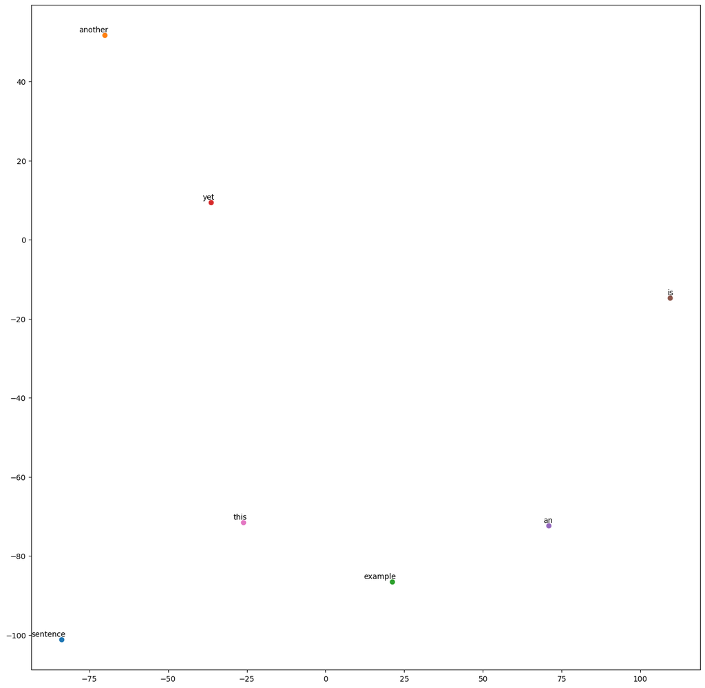

```
Similarity between 'word1' and 'word2': -0.052298497
```

```python
# use the following base code to help you in the homework

# Import necessary libraries
import gensim
from gensim.models import Word2Vec
from sklearn.manifold import TSNE
import matplotlib.pyplot as plt
import numpy as np

# Load your dataset (or use a preprocessed one)
# Example: sentences = [['this', 'is', 'an', 'example', 'sentence'], ['another', 'example', 'sentence']]
# Replace this with your own dataset
sentences = [['this', 'is', 'an', 'example', 'sentence'], ['another', 'example', 'sentence'],  ['yet', 'another', 'sentence']]

# Train Word2Vec model
model = Word2Vec(sentences, vector_size=100, window=5, min_count=1, workers=4)
model.train(sentences, total_examples=len(sentences), epochs=10)

# Get word embeddings
word_embeddings = model.wv

# Example of accessing word embeddings
print("Embedding for 'example':", word_embeddings['example'])

# Visualize word embeddings using t-SNE
def tsne_plot(model):
    labels = []
    wordvecs = []

    for word in model.wv.key_to_index:
        wordvecs.append(model.wv[word])
        labels.append(word)

    tsne_model = TSNE(perplexity=2, n_components=2, init='pca', n_iter=2500, random_state=23)
    new_values = tsne_model.fit_transform(np.array(wordvecs))

    x = []
    y = []
    for value in new_values:
        x.append(value[0])
        y.append(value[1])

    plt.figure(figsize=(16, 16))
    for i in range(len(x)):
        plt.scatter(x[i], y[i])
        plt.annotate(labels[i], xy=(x[i], y[i]), xytext=(5, 2), textcoords='offset points', ha='right', va='bottom')
    plt.show()

# Plot t-SNE visualization
tsne_plot(model)

# Example application: similarity between words
similarity = model.wv.similarity('example', 'sentence')
print("Similarity between 'word1' and 'word2':", similarity)
```

## Beginning of the code and the report

## Train the model

Training a Word2Vec model using Gensim and evaluating its performance through synonym detection, word analogies, and cosine similarity tests. The results demonstrate that the model is functioning correctly.

```python
from gensim.test.utils import datapath
from gensim.models.word2vec import Text8Corpus
from gensim.models import Word2Vec
import os
```

```python
import urllib.request
import zipfile
import os

# Create data directory if it doesn't exist
os.makedirs('data', exist_ok=True)

# Download text8 corpus if it doesn't exist
if not os.path.exists('data/text8'):
    print("Downloading text8 corpus...")
    urllib.request.urlretrieve('http://mattmahoney.net/dc/text8.zip', 'data/text8.zip')
    with zipfile.ZipFile('data/text8.zip', 'r') as zip_ref:
        zip_ref.extractall('data')
    os.remove('data/text8.zip')
    print("Download complete!")
else:
    print("text8 corpus already exists.")

# Load the corpus
corpus_path = "data/text8"
sentences = Text8Corpus(corpus_path)  # streamed, memory-efficient

# Train the Word2Vec model
model = Word2Vec(
    sentences=sentences,
    vector_size=100,
    window=5,
    min_count=5,
    workers=4,
    sg=1
)

# Save the model for reuse
model.save("word2vec_text8.model")

# Quick test: check most similar words
print("Words similar to 'king':")
print(model.wv.most_similar('king'))
```

```
text8 corpus already exists.
Words similar to 'king':
[('prince', 0.7316714525222778), ('valdemar', 0.730242908000946), ('queen', 0.7194070816040039), ('haakon', 0.7135719656944275), ('sobieski', 0.7131122350692749), ('wenceslaus', 0.710933268070221), ('canute', 0.7088093161582947), ('pretender', 0.7061196565628052), ('ethelred', 0.7059847712516785), (…
```

### Synonyms

The closest words are not necessarily synonyms but they are related.

```python
# Test synonyms for different word categories
print("\nSynonyms for different categories:")
print("\nAnimals:")
print(model.wv.most_similar('dog', topn=5))
print(model.wv.most_similar('cat', topn=5))
print(model.wv.most_similar('bird', topn=5))

print("\nVerbs:")
print(model.wv.most_similar('run', topn=5))
print(model.wv.most_similar('walk', topn=5))
print(model.wv.most_similar('jump', topn=5))

print("\nAdjectives:")
print(model.wv.most_similar('happy', topn=5))
print(model.wv.most_similar('sad', topn=5))
print(model.wv.most_similar('beautiful', topn=5))
```

```
Synonyms for different categories:

Animals:
[('dogs', 0.7581723928451538), ('rat', 0.7395033836364746), ('keeshond', 0.7381169199943542), ('hound', 0.7356107234954834), ('badger', 0.731963038444519)]
[('dog', 0.704437792301178), ('meow', 0.6869222521781921), ('prionailurus', 0.6788180470466614), ('albino', 0.6758354306221008), ('dogs', 0.6744892597198486)]
[('lizard', 0.7937998175621033), ('reptile', 0.7821523547172546), ('dinosaur', 0.7678254246711731), ('crocodile', 0.7530550956726074), ('birds', 0.752371072769165)]

Verbs:
[('running', 0.7597122192382812), ('runs', 0.7275339365005493), ('metrodome', 0.6632483005523682), ('booted', 0.6364001631736755), ('marketer', 0.6326138377189636)]
[('stumble', 0.6549756526947021), ('swindle', 0.6499879360198975), ('walked', 0.6462011337280273), ('blvd', 0.638469398021698), ('shoot', 0.631173312664032)]
[('jumps', 0.7590292096138), ('kickoff', 0.7285811901092529), ('tee', 0.7066131830215454), ('strikeout', 0.7058447599411011), ('diver', 0.7046801447868347)]

Adjectives:
[('quiet', 0.7406357526779175), ('happily', 0.7057336568832397), ('laugh', 0.7014181017875671), ('agony', 0.7006790041923523), ('lucky', 0.7004210352897644)]
[('sleepless', 0.720062255859375), ('infamy', 0.7023371458053589), ('duckling', 0.7010198831558228), ('wanton', 0.7010135054588318), ('gloom', 0.700286328792572)]
[('beauty', 0.7283231616020203), ('lovely', 0.7107654809951782), ('beautifully', 0.6700142621994019), ('handsome', 0.6682111620903015), ('desolate', 0.6638661026954651)]
```

### Word Analogies

```python
print("\nWord Analogies:")
print("\nking - man + woman = ?")
print(model.wv.most_similar(positive=['king', 'woman'], negative=['man'], topn=3))
print("\nengland - germany + italy = ?")
print(model.wv.most_similar(positive=['england', 'italy'], negative=['germany'], topn=3))

print("\nbrother - man + woman = ?")
print(model.wv.most_similar(positive=['brother', 'woman'], negative=['man'], topn=3))
```

```
Word Analogies:

king - man + woman = ?
[('daughter', 0.6639537215232849), ('sigismund', 0.6474975943565369), ('queen', 0.6336977481842041)]

england - germany + italy = ?
[('scotland', 0.7454700469970703), ('brittany', 0.6660104990005493), ('northumbria', 0.6554118990898132)]

brother - man + woman = ?
[('wife', 0.7887973189353943), ('daughter', 0.7638538479804993), ('mother', 0.71168452501297)]
```

```python
print("\nOdd One Out Tests:")
print("\nIn ['car', 'bus', 'train', 'apple']:")
print(model.wv.doesnt_match(['car', 'bus', 'train', 'apple']))

print("\nIn ['red', 'blue', 'green', 'dog']:")
print(model.wv.doesnt_match(['red', 'blue', 'green', 'dog']))

print("\nIn ['monday', 'tuesday', 'wednesday', 'january']:")
print(model.wv.doesnt_match(['monday', 'tuesday', 'wednesday', 'january']))
```

```
Odd One Out Tests:

In ['car', 'bus', 'train', 'apple']:
apple

In ['red', 'blue', 'green', 'dog']:
dog

In ['monday', 'tuesday', 'wednesday', 'january']:
january
```

### Testing the Cosine similarities

As we expect the car and truck to be more similar than the car and cat.

```python
# Testing the Cosine similarities
# Comparing similarities between related and unrelated word pairs
from numpy import dot
from numpy.linalg import norm

def cosine_similarity(vec1, vec2):
    return dot(vec1, vec2) / (norm(vec1) * norm(vec2))

# Get word vectors from the model
vector_car = model.wv['car']
vector_truck = model.wv['truck']
vector_cat = model.wv['cat']

sim_car_truck = cosine_similarity(vector_car, vector_truck)
sim_car_cat = cosine_similarity(vector_car, vector_cat)

print("Cosine similarity (car, truck):", sim_car_truck)
print("Cosine similarity (car, cat):", sim_car_cat)
```

```
Cosine similarity (car, truck): 0.7527086
Cosine similarity (car, cat): 0.35848162
```

```python
# Now lets see the Euclidean distance between the vectors

dist_car_truck = norm(vector_car - vector_truck)
dist_car_cat = norm(vector_car - vector_cat)

print("Euclidean distance (car, truck):",  dist_car_truck)
print("Euclidean distance (car, cat):", dist_car_cat)
```

```
Euclidean distance (car, truck): 2.2962592
Euclidean distance (car, cat): 3.6803107
```

### Word Embedding Visualization with t-SNE

t-SNE is employed to visualize word embeddings in two dimensions, allowing us to examine whether high-frequency words and thematic word groups naturally cluster based on their semantic relationships.

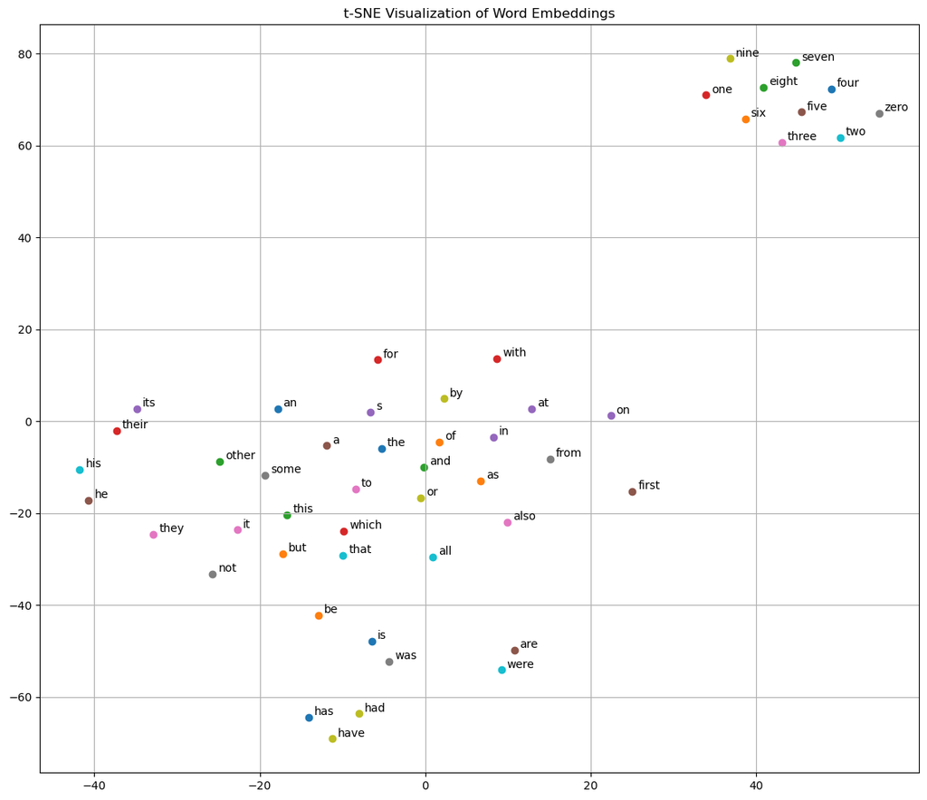

```python
def visualize_word_embeddings(words, vectors, title="t-SNE Visualization of Word Embeddings", figsize=(14, 12)):
    """Visualize word embeddings using t-SNE dimensionality reduction.

    Args:
        words: List of words to visualize
        vectors: Corresponding word vectors
        title: Plot title
        figsize: Figure dimensions
    """
    # Reduce dimensionality using t-SNE
    tsne = TSNE(n_components=2, perplexity=10, n_iter=3000, random_state=42)
    word_vectors_2d = tsne.fit_transform(vectors)

    # Create visualization
    plt.figure(figsize=figsize)
    for i, word in enumerate(words):
        x, y = word_vectors_2d[i]
        plt.scatter(x, y)
        plt.annotate(word, xy=(x, y), xytext=(5, 2), textcoords='offset points')

    plt.title(title)
    plt.grid(True)
    plt.show()

# Get frequent words and their vectors
frequent_words = list(model.wv.index_to_key)[:50]
frequent_word_vectors = model.wv[frequent_words]

# Visualize embeddings
visualize_word_embeddings(frequent_words, frequent_word_vectors)
```

The t-SNE visualization shows semantic clusters, with related words positioned closer together. The spatial arrangement reflects contextual relationships from the training data. We can see that clearly the digits are grouped together.

Trying with a different set of words

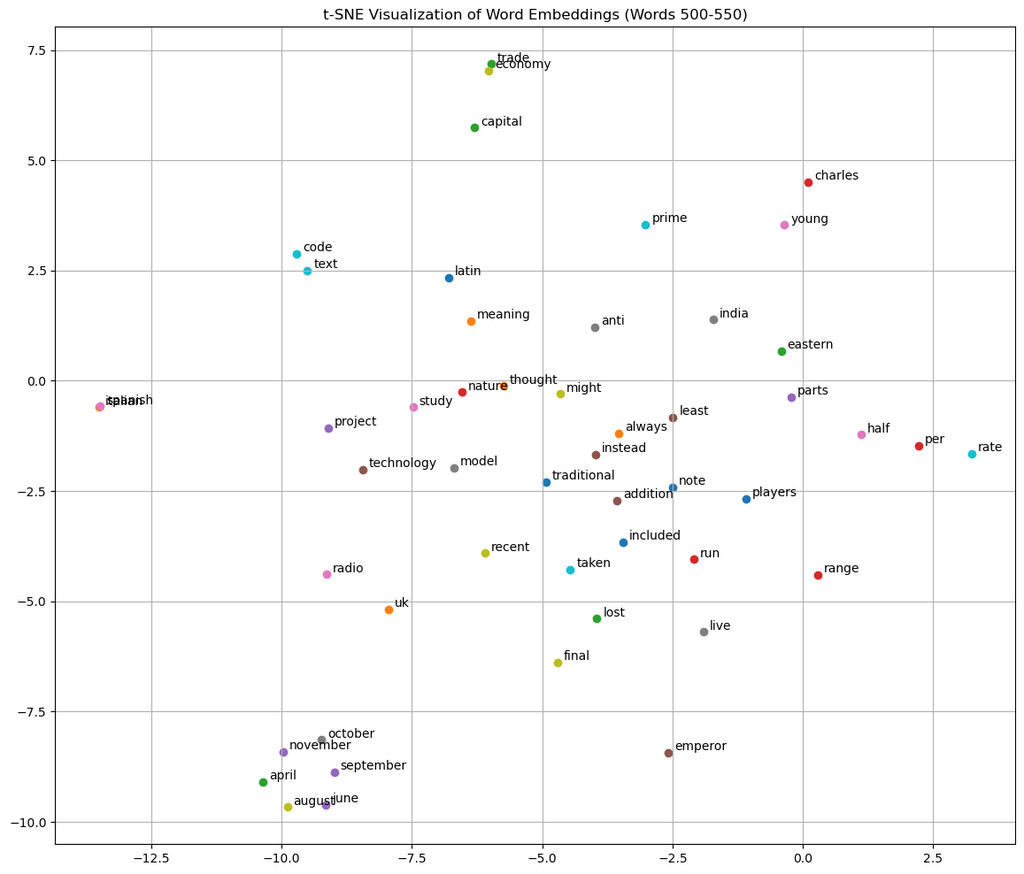

```python
# Get word vectors for words 500-550
frequent_words = list(model.wv.index_to_key)[500:550]
frequent_word_vectors = model.wv[frequent_words]

# Visualize embeddings using the existing function
visualize_word_embeddings(
    frequent_words,
    frequent_word_vectors,
    title="t-SNE Visualization of Word Embeddings (Words 500-550)"
)
```

Looking at the t-SNE visualization, we can observe several distinct clusters. Words like 'november', 'april', and 'august' group together, while technology-related terms like 'technology', 'model', and 'traditional' appear. There's also a noticeable cluster of abstract concepts like 'meaning' and 'thought' in the central area.

## Creating clusters for specific groups of words

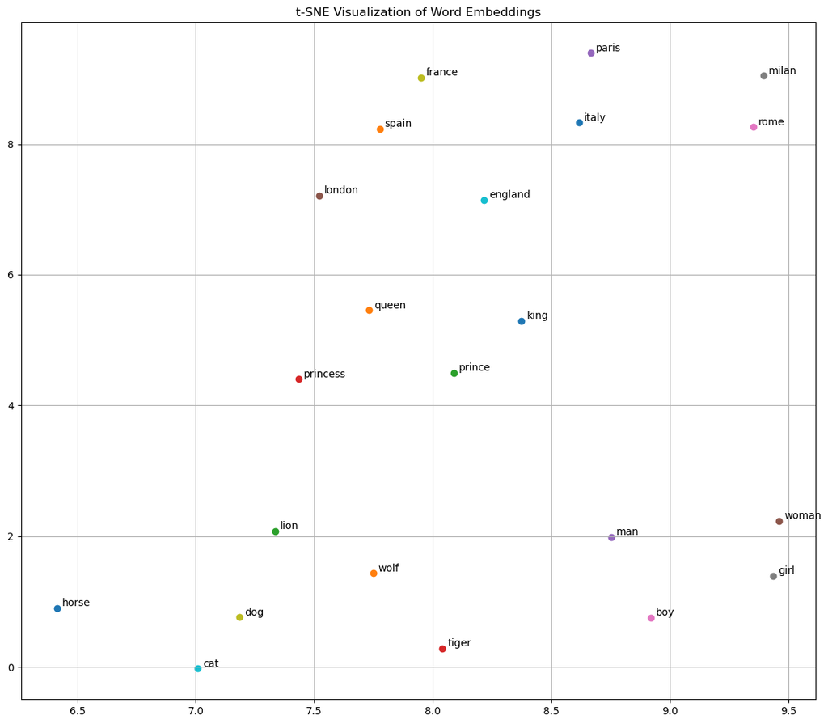

```python
# Define thematic word groups
royalty_words = ['king', 'queen', 'prince', 'princess']
gender_words = ['man', 'woman', 'boy', 'girl']
animal_words = ['dog', 'cat', 'horse', 'wolf', 'lion', 'tiger']
city_words = ['paris', 'london', 'rome', 'milan']
country_words = ['france', 'england', 'italy', 'spain']

# Combine all words
words = royalty_words + gender_words + animal_words + city_words + country_words

# Get word vectors
word_vectors = np.array([model.wv[word] for word in words])

# Apply t-SNE
tsne = TSNE(n_components=2, perplexity=10, n_iter=3000, random_state=42)
word_vectors_2d = tsne.fit_transform(word_vectors)

# Visualize embeddings using the existing function
visualize_word_embeddings(
    words,
    word_vectors_2d,
    title="t-SNE Visualization of Word Embeddings"
)
```

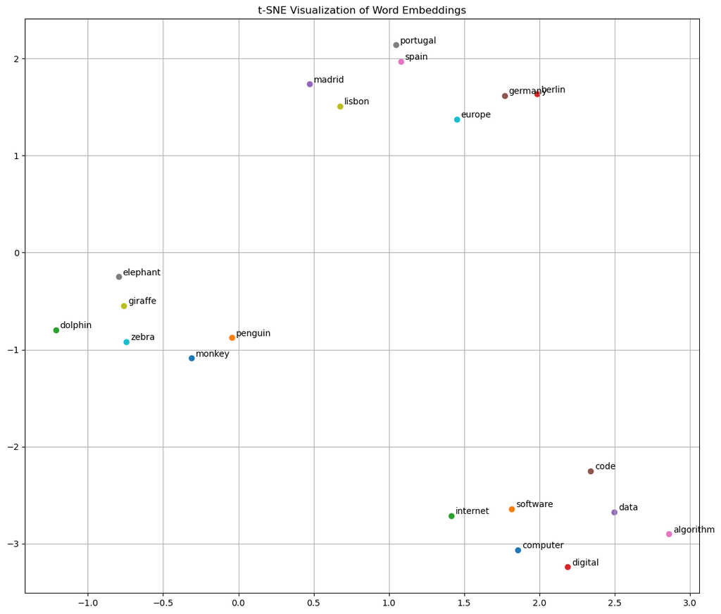

```python
# Define thematic word groups
tech_words = ['computer', 'software', 'internet', 'digital', 'data', 'code', 'algorithm']
animal_words = ['elephant', 'giraffe', 'zebra', 'monkey', 'penguin', 'dolphin']
europe_words = ['berlin', 'madrid', 'germany', 'spain', 'portugal', 'lisbon', 'europe']

# Combine all words
words = tech_words + animal_words + europe_words

# Get word vectors and apply t-SNE
word_vectors = np.array([model.wv[word] for word in words])
tsne = TSNE(n_components=2, perplexity=10, n_iter=3000, random_state=42)
word_vectors_2d = tsne.fit_transform(word_vectors)

# Visualize embeddings using the existing function
visualize_word_embeddings(
    words,
    word_vectors_2d,
    title="t-SNE Visualization of Word Embeddings"
)
```

Similar to the previous visualization, all the clusters are distinct in the t-SNE visualization.

### Step 1: Import Libraries

```python
# Step 1: Import libraries
import gensim
from gensim.models import Word2Vec
from gensim.utils import simple_preprocess
from sklearn.datasets import fetch_20newsgroups
from sklearn.model_selection import train_test_split
from sklearn.linear_model import LogisticRegression
from sklearn.metrics import classification_report, confusion_matrix, accuracy_score
import numpy as np
import matplotlib.pyplot as plt
import seaborn as sns
```

```python
# Step 2: Load dataset
newsgroups = fetch_20newsgroups(subset='all', remove=('headers', 'footers', 'quotes'))
texts, labels = newsgroups.data, newsgroups.target
```

### Step 3: Text preprocessing

```python
# Step 3: Text preprocessing
def preprocess(texts):
    return [simple_preprocess(text, deacc=True) for text in texts]

tokenized_texts = preprocess(texts)
```

### Step 4: Train Word2Vec Model

```python
model = Word2Vec(sentences=tokenized_texts, vector_size=100, window=5, min_count=2, workers=4)
```

### Step 5: Create Document Vectors/ Embeddings

```python
# Step 5: Create document embeddings (average vectors)
def document_vector(tokens, model):
    embeddings = [model.wv[word] for word in tokens if word in model.wv]
    return np.mean(embeddings, axis=0) if embeddings else np.zeros(model.vector_size)

# Create embeddings for all documents
doc_vectors = np.array([document_vector(tokens, model) for tokens in tokenized_texts])
```

### Step 6: Split the dataset into training and testing

```python
# Step 6: Split dataset into training and testing
X_train, X_test, y_train, y_test = train_test_split(doc_vectors, labels, test_size=0.2, random_state=42)
```

### Step 7: Train the classifier

```python
# Step 7: Train classifier
clf = LogisticRegression(max_iter=1000)
clf.fit(X_train, y_train)
```

```
LogisticRegression(max_iter=1000)
```

### Step 8: Prediction and Evaluation

```python
y_pred = clf.predict(X_test)
accuracy = accuracy_score(y_test, y_pred)
print("Accuracy:", accuracy)
print("Classification Report:\n", classification_report(y_test, y_pred, target_names=newsgroups.target_names))
```

```
Accuracy: 0.4920424403183024
Classification Report:
                           precision    recall  f1-score   support

             alt.atheism       0.27      0.28      0.28       151
           comp.graphics       0.48      0.44      0.46       202
 comp.os.ms-windows.misc       0.53      0.47      0.50       195
comp.sys.ibm.pc.hardware       0.36      0.40      0.38       183
   comp.sys.mac.hardware       0.47      0.33      0.39       205
          comp.windows.x       0.64      0.67      0.65       215
            misc.forsale       0.65      0.64      0.65       193
               rec.autos       0.31      0.46      0.37       196
         rec.motorcycles       0.34      0.39      0.36       168
      rec.sport.baseball       0.55      0.49      0.52       211
        rec.sport.hockey       0.62      0.68      0.65       198
               sci.crypt       0.65      0.60      0.62       201
         sci.electronics       0.45      0.39      0.42       202
                 sci.med       0.52      0.61      0.56       194
               sci.space       0.53      0.60      0.56       189
  soc.religion.christian       0.50      0.69      0.58       202
      talk.politics.guns       0.50      0.52      0.51       188
   talk.politics.mideast       0.61      0.59      0.60       182
      talk.politics.misc       0.40      0.31      0.35       159
      talk.religion.misc       0.20      0.04      0.06       136

                accuracy                           0.49      3770
               macro avg       0.48      0.48      0.47      3770
            weighted avg       0.49      0.49      0.48      3770
```

### Step 9: Visualize confusion matrix

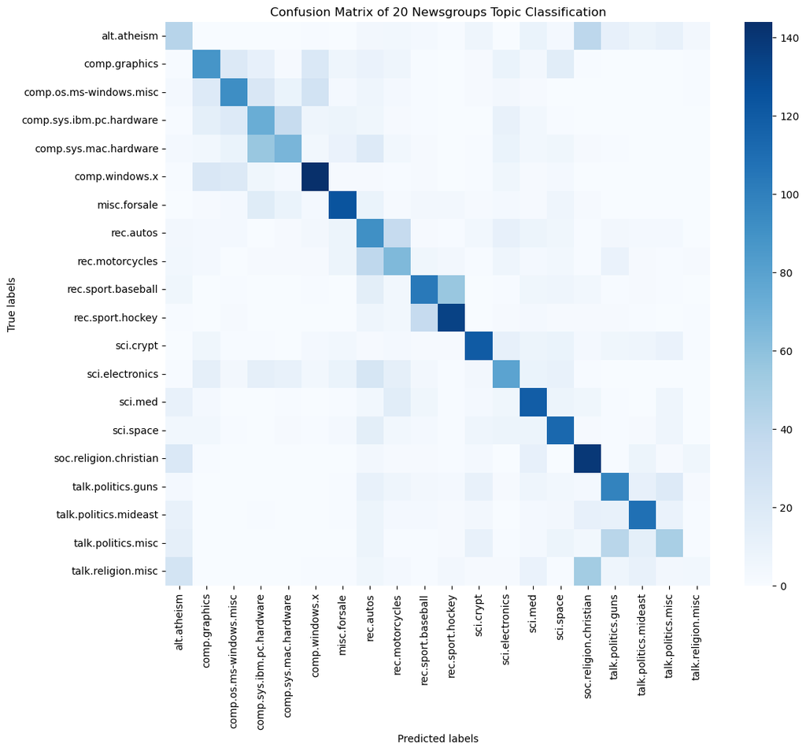

```python
# Step 9: Visualize Confusion Matrix
plt.figure(figsize=(12,10))
cm = confusion_matrix(y_test, y_pred)
sns.heatmap(cm, annot=False, cmap='Blues', xticklabels=newsgroups.target_names, yticklabels=newsgroups.target_names)
plt.xlabel('Predicted labels')
plt.ylabel('True labels')
plt.title('Confusion Matrix of 20 Newsgroups Topic Classification')
plt.show()
```

### Visualizing Document Embeddings with t-SNE

As a complementary step to classification, here we visualized the 20 Newsgroups documents in 2D using t-distributed Stochastic Neighbor Embedding (t-SNE). This provided an intuitive understanding of how effectively the Word2Vec embeddings separated documents by topic in semantic space.

**Objective**

- Project the high-dimensional document vectors (generated via average Word2Vec embeddings) into a 2D space to visually inspect whether documents from the same topic naturally cluster together.

**Methodology**

1. Input Vectors: Each document was represented by the average of its constituent word embeddings from our trained Word2Vec model.
2. Dimensionality Reduction:
- t-SNE was used with a perplexity of 40 and 3000 iterations.
- t-SNE captures local structure, so nearby points represent semantically similar documents.
3. Color Encoding:
- Each dot represents a single document from the 20 Newsgroups dataset.
- Dots are color-coded by their assigned topic labels.

```
Computing t-SNE visualization...
```

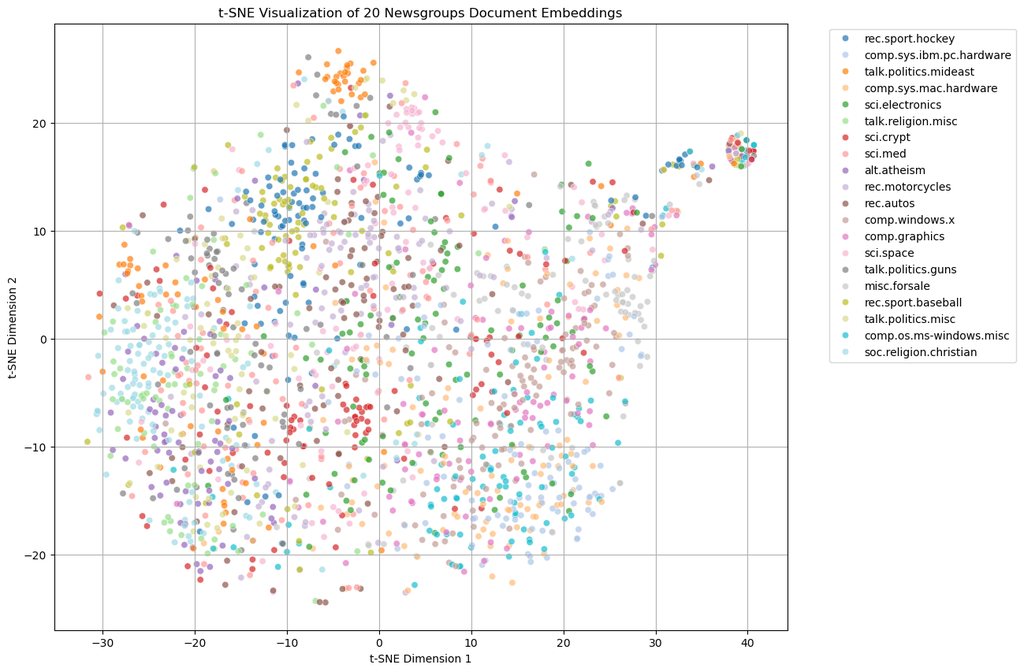

```python
# Step 10: t-SNE Visualization of document embeddings
print("Computing t-SNE visualization...")
tsne = TSNE(n_components=2, perplexity=40, n_iter=3000, random_state=42)
doc_vecs_2d = tsne.fit_transform(doc_vectors[:2000])  # Limiting to first 2000 documents for visualization clarity

plt.figure(figsize=(12,10))
sns.scatterplot(x=doc_vecs_2d[:,0], y=doc_vecs_2d[:,1], hue=[newsgroups.target_names[label] for label in labels[:2000]],
                palette='tab20', legend='full', alpha=0.7)
plt.title("t-SNE Visualization of 20 Newsgroups Document Embeddings")
plt.xlabel("t-SNE Dimension 1")
plt.ylabel("t-SNE Dimension 2")
plt.legend(bbox_to_anchor=(1.05, 1), loc='upper left')
plt.grid(True)
plt.show()
```

# Hyperparameter Tuning

```
Training model 1/5: {'vector_size': 100, 'window': 5, 'sg': 1, 'epochs': 10}
Accuracy: 0.6435013262599469
Classification Report:
                           precision    recall  f1-score   support

             alt.atheism       0.37      0.44      0.40       151
           comp.graphics       0.64      0.61      0.63       202
 comp.os.ms-windows.misc       0.60      0.63      0.62       195
comp.sys.ibm.pc.hardware       0.54      0.57      0.55       183
   comp.sys.mac.hardware       0.65      0.53      0.58       205
          comp.windows.x       0.85      0.78      0.81       215
            misc.forsale       0.72      0.66      0.69       193
               rec.autos       0.45      0.65      0.53       196
         rec.motorcycles       0.58      0.64      0.61       168
      rec.sport.baseball       0.78      0.74      0.76       211
        rec.sport.hockey       0.83      0.82      0.82       198
               sci.crypt       0.78      0.71      0.74       201
         sci.electronics       0.62      0.58      0.60       202
                 sci.med       0.75      0.79      0.77       194
               sci.space       0.68      0.73      0.71       189
  soc.religion.christian       0.60      0.79      0.68       202
      talk.politics.guns       0.60      0.68      0.64       188
   talk.politics.mideast       0.73      0.70      0.71       182
      talk.politics.misc       0.56      0.51      0.53       159
      talk.religion.misc       0.25      0.04      0.06       136

                accuracy                           0.64      3770
               macro avg       0.63      0.63      0.62      3770
            weighted avg       0.64      0.64      0.64      3770


Training model 2/5: {'vector_size': 200, 'window': 5, 'sg': 1, 'epochs': 10}
Accuracy: 0.6578249336870027
Classification Report:
                           precision    recall  f1-score   support

             alt.atheism       0.40      0.44      0.42       151
           comp.graphics       0.65      0.63      0.64       202
 comp.os.ms-windows.misc       0.62      0.61      0.61       195
comp.sys.ibm.pc.hardware       0.55      0.57      0.56       183
```

[output cut: 102 more lines]

```
                 sci.med       0.79      0.83      0.81       194
               sci.space       0.69      0.74      0.71       189
  soc.religion.christian       0.58      0.79      0.67       202
      talk.politics.guns       0.64      0.70      0.67       188
   talk.politics.mideast       0.75      0.72      0.74       182
      talk.politics.misc       0.56      0.54      0.55       159
      talk.religion.misc       0.29      0.05      0.09       136

                accuracy                           0.66      3770
               macro avg       0.65      0.65      0.64      3770
            weighted avg       0.66      0.66      0.66      3770


Best hyperparameters: {'vector_size': 100, 'window': 10, 'sg': 1, 'epochs': 10}
Best accuracy: 0.6742705570291777
```

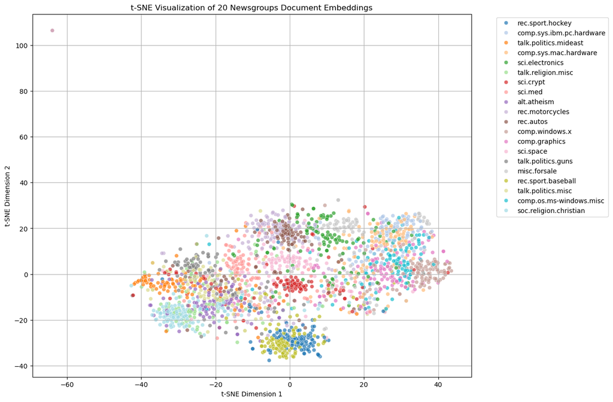

```python
param_grid = [
    {"vector_size": 100, "window": 5, "sg": 1, "epochs": 10},
    {"vector_size": 200, "window": 5, "sg": 1, "epochs": 10},
    {"vector_size": 100, "window": 10, "sg": 1, "epochs": 10},
    {"vector_size": 100, "window": 5, "sg": 0, "epochs": 10},
    {"vector_size": 100, "window": 5, "sg": 1, "epochs": 20}
]

results = []

for i, params in enumerate(param_grid):
    print(f"\nTraining model {i+1}/{len(param_grid)}: {params}")

    # Step 5: Train Word2Vec model with current parameters
    model = Word2Vec(sentences=tokenized_texts, vector_size=params["vector_size"], window=params["window"],
                     sg=params["sg"], epochs=params["epochs"], min_count=2, workers=4)

    # Step 6: Create document embeddings (average vectors)
    def document_vector(tokens, model):
        embeddings = [model.wv[word] for word in tokens if word in model.wv]
        return np.mean(embeddings, axis=0) if embeddings else np.zeros(model.vector_size)

    # Create embeddings for all documents
    doc_vectors = np.array([document_vector(tokens, model) for tokens in tokenized_texts])

    # Step 7: Split dataset into training and testing
    X_train, X_test, y_train, y_test = train_test_split(doc_vectors, labels, test_size=0.2, random_state=42)

    # Step 8: Train classifier
    clf = LogisticRegression(max_iter=1000)
    clf.fit(X_train, y_train)

    # Step 9: Predict and evaluate
    y_pred = clf.predict(X_test)
    accuracy = accuracy_score(y_test, y_pred)
    print("Accuracy:", accuracy)
    print("Classification Report:\n", classification_report(y_test, y_pred, target_names=newsgroups.target_names))

    results.append({"params": params, "accuracy": accuracy})

# Step 10: Identify best model
best_result = max(results, key=lambda x: x['accuracy'])
print("\nBest hyperparameters:", best_result['params'])
print("Best accuracy:", best_result['accuracy'])

# Visualization using best hyperparameters
tsne = TSNE(n_components=2, perplexity=40, n_iter=3000, random_state=42)
doc_vecs_2d = tsne.fit_transform(doc_vectors[:2000])

plt.figure(figsize=(12,10))
sns.scatterplot(x=doc_vecs_2d[:,0], y=doc_vecs_2d[:,1], hue=[newsgroups.target_names[label] for label in labels[:2000]],
                palette='tab20', legend='full', alpha=0.7)
plt.title("t-SNE Visualization of 20 Newsgroups Document Embeddings")
plt.xlabel("t-SNE Dimension 1")
plt.ylabel("t-SNE Dimension 2")
plt.legend(bbox_to_anchor=(1.05, 1), loc='upper left')
plt.grid(True)
plt.show()
```

Experiment: Impact of Word2Vec Hyperparameters on 20 Newsgroups Document Classification

### Objective

To systematically analyze how variations in Word2Vec hyperparameters impact the performance of document classification on the 20 Newsgroups dataset.

### Experiment Setup

- **Dataset**: 20 Newsgroups dataset with 18,846 documents across 20 distinct topics.
- **Word2Vec Hyperparameters Evaluated**:
  - `vector_size`: 100 vs 200
  - `window`: 5 vs 10
  - `sg`: Skip-gram (1) vs CBOW (0)
  - `epochs`: 10 vs 20
- **Document Embeddings**: Averaged Word2Vec embeddings from each document.
- **Classifier**: Logistic Regression
- **Evaluation Metrics**: Accuracy, precision, recall, F1-score on an 80/20 train-test split.

### Results

[output not shown]

### Observations

- **Increasing window size** from 5 to 10 provided a notable improvement in classification accuracy (Run 3 vs Run 1).
- **Increasing vector size** from 100 to 200 slightly improved performance, indicating better semantic representation (Run 2 vs Run 1).
- **Skip-gram model (sg=1)** clearly outperformed the CBOW model (sg=0) in this scenario (Run 1 vs Run 4).
- **Increasing epochs** from 10 to 20 offered minor improvements, suggesting diminishing returns beyond a certain number of epochs (Run 5 vs Run 1).

### Conclusion

The results demonstrate that the choice of Word2Vec hyperparameters significantly affects the quality of document embeddings and consequently classification accuracy. Specifically, using a larger window size (10) with skip-gram models provided the most substantial gains. Thus, careful hyperparameter tuning can notably enhance the effectiveness of Word2Vec embeddings for topic classification tasks.

## Summary of the document classification using Word2Vec embeddings

## Objective

To assess the effectiveness of Word2Vec-generated document embeddings in representing documents for accurate topic classification within the 20 Newsgroups dataset.

## Methodology

1. **Data Preparation**
   - Utilized the 20 Newsgroups dataset, comprising approximately 18,846 documents across 20 distinct categories.
2. **Document Representation**
   - Documents were represented using averaged Word2Vec embeddings derived from trained word vectors.
3. **Classification**
   - A Logistic Regression classifier was trained on these document embeddings to categorize documents. The dataset was split into an 80/20 training-test set.
4. **Evaluation**
   - Model performance was measured using accuracy, precision, recall, and F1-score metrics, supported by detailed classification reports and confusion matrices.

## Results Analysis

The confusion matrix and classification metrics highlighted the model's capability to differentiate between diverse topic categories effectively. Certain closely related topics exhibited overlap, reflecting their semantic proximity.

## Observations on the strenghts and weaknesses of Word2Vec

### Conclusion

The results demonstrate that the choice of Word2Vec hyperparameters significantly affects the quality of document embeddings and consequently classification accuracy. Specifically, using a larger window size (10) with skip-gram models provided the most substantial gains. Thus, careful hyperparameter tuning can notably enhance the effectiveness of Word2Vec embeddings for topic classification tasks.

### Strengths of Word2Vec

1. **Efficient and Scalable**: Word2Vec efficiently handles large datasets like 20 Newsgroups, providing quick training and embeddings generation.
2. **Captures Semantic Relationships**: It successfully captures contextual relationships between words, aiding in accurate topic classification.
3. **Ease of Use**: Simple to implement and integrate into classification and clustering workflows.
4. **Adaptability**: Can be retrained or fine-tuned on different or specialized datasets to enhance performance.

### Weaknesses and Limitations

1. **Context-Agnostic**: Static embeddings lack the ability to represent context-specific meanings of words.
2. **Lack of Syntax and Word Order**: Ignores grammar and syntax, affecting tasks that require deeper semantic understanding.
3. **Rare Word Handling**: Struggles to effectively represent low-frequency words, which might impact the model's ability to generalize.
4. **Document Vector Averaging**: Averaging word vectors may dilute specific semantic nuances within documents, limiting classification accuracy.